# Desafios e Requisitos dos Projetos Analiticos

Julho de 2021

Turma: **FGV TBABD-8**  
Professor: **Rafael Lychowski**  
Autores: **Davi Almeida Ferreira**, **Jucelino Ribeiro Carvalho** e **Guilherme Rocha Gomez**

### Metodologia utilizada

Utilizaremos para a realização deste trabalho a metodologia CRISP-DM

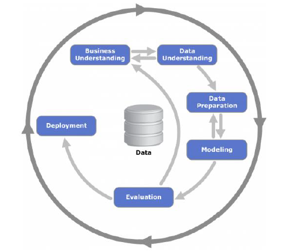

### Entendimento do Negócio

A Vale pretende prever o desgaste de rodas de vagões e fornecer uma visão futura da frota de rodeiros, para melhor planejamento de menutanção e compra de componentes.

**Problema:** Prever se o friso da roda estaá abaixo de 26 mm na próxima leitura.

1. A área não tem visibilidade do que vai contecer com o ativos, antecipando as trocas;
2. A cada troca o rodeiro é usinado, e sua vida útil reduzida;
3. Incapacidade de visuzalização de desgastes acelerados em toda a frota de vagões
4. Muitos vagões apresentam reinciência de trocas, e os fatores não são bem claros;
- Base de dados: EFC_WAYSIDES.csv
- Variável dependente: ESPESSURA_FRISO_RODA
- Método: Supervisionado
- Submétodo: Classificação
- Objetivo: Identificar quais os frisos terão menos que 26 cm de friso no próximo ciclo.

### Entendimento dos Dados

#### Verificação da qualidade dos Dados

```r
"Verificando o 'Schema' dos dados"
```

```
## [1] "Verificando o 'Schema' dos dados"
```

```r
printSchema(df)
```

```
## root
##  |-- ROW_ID: string (nullable = true)
##  |-- DATA_HORA_LEITURA: timestamp (nullable = true)
##  |-- CODIGO_VAGAO: string (nullable = true)
##  |-- CODIGO_RODEIRO: string (nullable = true)
##  |-- CODIGO_RODA: string (nullable = true)
##  |-- LADO_RODA: string (nullable = true)
##  |-- EIXO_VAGAO: double (nullable = true)
##  |-- CICLO_RODEIRO: string (nullable = true)
##  |-- TRAIN_ID: string (nullable = true)
##  |-- SENTIDO_TREM: string (nullable = true)
##  |-- VELOCIDADE_ENTRADA_TREM: double (nullable = true)
##  |-- VELOCIDADE_SAIDA_TREM: double (nullable = true)
##  |-- POSICAO_VAGAO_COMPOSICAO: double (nullable = true)
##  |-- ANGULO_FRISO_RODA: double (nullable = true)
##  |-- ALTURA_FRISO_RODA: double (nullable = true)
##  |-- ESPESSURA_FRISO_RODA: double (nullable = true)
##  |-- CAVA_RODA: double (nullable = true)
##  |-- ANGULO_ATAQUE_EIXO_FRONTAL_TRUQUE: double (nullable = true)
##  |-- ANGULO_ATAQUE_EIXO_TRASEIRO_TRUQUE: double (nullable = true)
##  |-- TRACKING_POSITION_EIXO_FRONTAL_TRUQUE: double (nullable = true)
##  |-- TRACKING_POSITION_EIXO_TRASEIRO_TRUQUE: double (nullable = true)
##  |-- ROTACAO_EIXO: double (nullable = true)
##  |-- ALINHAMENTO_ENTRE_EIXOS_(IAM): double (nullable = true)
##  |-- DESLOCAMENTO_ENTRE_EIXOS_(SHIFT): double (nullable = true)
##  |-- TRACKING_ERROR_(TE): double (nullable = true)
##  |-- SERPENTEAMENTO_(HUNTING): double (nullable = true)
##  |-- friso_baixo: double (nullable = false)
##  |-- Dia: date (nullable = true)
```

##### Verificar a existencia de dados faltantes

```r
#Verificando qualidade dos dados.
# Davi 1 - modifiquei a função para poder ser utilizada com mais de um data_frame
test_null <- function(data_frame,coluna){
   try(data_frame %>% where(.,isNull(.[[coluna]]))%>%count(.), silent = TRUE)}

test_isNAN <- function(data_frame,coluna){
  try(data_frame %>% where(.,isNaN(.[[coluna]]))%>%count(.), silent = TRUE)}

test_vazio <- function(data_frame,coluna){
  try(data_frame %>% where(.,.[[coluna]]== "")  %>% count(.), silent = TRUE)}

test_zero <- function(data_frame,coluna){
  try(data_frame %>% where(.,.[[coluna]]== 0)  %>% count(.), silent = TRUE)}

total <- count(df)

class(df$ROW_ID)
```

```
## [1] "Column"
## attr(,"package")
## [1] "SparkR"
```

```r
x <- 0
Tipo_de_dados <- 0

# Criando a coluna de tipo de dados
for (i in 1:length(colnames(df))){
  x[i] <- dtypes(df)[[i]][1]
  Tipo_de_dados[i] <- dtypes(df)[[i]][2]
}
tipo_dados <- as.data.frame(Tipo_de_dados,x)

cont_prob <- data.frame()
for (coluna in colnames(df)){
#As colunas no dataframe serão linhas neste relatório.

  cont_prob[coluna,"Nulo"]  <- ifelse(is.numeric(test_null(df,coluna)),test_null(df,coluna),0)
  cont_prob[coluna,"% Nulo"]  <- ifelse(is.numeric(test_null(df,coluna)),
                                        paste(round(((test_null(df,coluna)/total)*100),2),"%",sep=""),
                                        "0%")
  cont_prob[coluna,"isNAN"] <-    ifelse(is.numeric(test_isNAN(df,coluna)),test_isNAN(df,coluna),0)
  cont_prob[coluna,"% isNAN"]  <- ifelse(is.numeric(test_isNAN(df,coluna)),
                                        paste(round(((test_isNAN(df,coluna)/total)*100),2),"%",sep=""),
                                        "0%")
  cont_prob[coluna,"Vazio"] <- ifelse(is.numeric(test_vazio(df,coluna)),test_vazio(df,coluna),0)
  cont_prob[coluna,"% Vazio"]  <- ifelse(is.numeric(test_vazio(df,coluna)),
                                        paste(round(((test_vazio(df,coluna)/total)*100),2),"%",sep=""),
                                        "0%")
  cont_prob[coluna,"Zero"]  <- ifelse(is.numeric(test_zero(df,coluna)),test_zero(df,coluna),0)
  cont_prob[coluna,"% Zero"]  <- ifelse(is.numeric(test_zero(df,coluna)),
                                        paste(round(((test_zero(df,coluna)/total)*100),2),"%",sep=""),
                                        "0%")
}

cont_prob <- cbind(cont_prob,tipo_dados)

cont_prob %>% kable(., format = "html",row.names = T, digits = 2) %>%
  kable_styling(bootstrap_options = c("striped","hover","condensed","responsive"))
```

|  | Nulo | % Nulo | isNAN | % isNAN | Vazio | % Vazio | Zero | % Zero | Tipo_de_dados |
| --- | --- | --- | --- | --- | --- | --- | --- | --- | --- |
| ROW_ID | 0 | 0% | 0 | 0% | 0 | 0% | 0 | 0% | string |
| DATA_HORA_LEITURA | 0 | 0% | 0 | 0% | 0 | 0% | 0 | 0% | timestamp |
| CODIGO_VAGAO | 0 | 0% | 0 | 0% | 0 | 0% | 0 | 0% | string |
| CODIGO_RODEIRO | 0 | 0% | 0 | 0% | 0 | 0% | 0 | 0% | string |
| CODIGO_RODA | 0 | 0% | 0 | 0% | 0 | 0% | 0 | 0% | string |
| LADO_RODA | 0 | 0% | 0 | 0% | 0 | 0% | 0 | 0% | string |
| EIXO_VAGAO | 0 | 0% | 0 | 0% | 0 | 0% | 0 | 0% | double |
| CICLO_RODEIRO | 0 | 0% | 0 | 0% | 0 | 0% | 0 | 0% | string |
| TRAIN_ID | 0 | 0% | 0 | 0% | 0 | 0% | 0 | 0% | string |
| SENTIDO_TREM | 0 | 0% | 0 | 0% | 0 | 0% | 0 | 0% | string |
| VELOCIDADE_ENTRADA_TREM | 0 | 0% | 0 | 0% | 0 | 0% | 0 | 0% | double |
| VELOCIDADE_SAIDA_TREM | 0 | 0% | 0 | 0% | 0 | 0% | 0 | 0% | double |
| POSICAO_VAGAO_COMPOSICAO | 0 | 0% | 0 | 0% | 0 | 0% | 0 | 0% | double |
| ANGULO_FRISO_RODA | 287408 | 9.69% | 0 | 0% | 0 | 0% | 0 | 0% | double |
| ALTURA_FRISO_RODA | 2354 | 0.08% | 0 | 0% | 0 | 0% | 0 | 0% | double |
| ESPESSURA_FRISO_RODA | 11146 | 0.38% | 0 | 0% | 0 | 0% | 0 | 0% | double |
| CAVA_RODA | 607049 | 20.46% | 0 | 0% | 0 | 0% | 348 | 0.01% | double |
| ANGULO_ATAQUE_EIXO_FRONTAL_TRUQUE | 19723 | 0.66% | 0 | 0% | 0 | 0% | 402659 | 13.57% | double |
| ANGULO_ATAQUE_EIXO_TRASEIRO_TRUQUE | 19723 | 0.66% | 0 | 0% | 0 | 0% | 434196 | 14.64% | double |
| TRACKING_POSITION_EIXO_FRONTAL_TRUQUE | 19723 | 0.66% | 0 | 0% | 0 | 0% | 16148 | 0.54% | double |
| TRACKING_POSITION_EIXO_TRASEIRO_TRUQUE | 19723 | 0.66% | 0 | 0% | 0 | 0% | 19538 | 0.66% | double |
| ROTACAO_EIXO | 19723 | 0.66% | 0 | 0% | 0 | 0% | 2946269 | 99.33% | double |
| ALINHAMENTO_ENTRE_EIXOS_(IAM) | 19731 | 0.67% | 0 | 0% | 0 | 0% | 308248 | 10.39% | double |
| DESLOCAMENTO_ENTRE_EIXOS_(SHIFT) | 19731 | 0.67% | 0 | 0% | 0 | 0% | 1170583 | 39.46% | double |
| TRACKING_ERROR_(TE) | 19763 | 0.67% | 0 | 0% | 0 | 0% | 16627 | 0.56% | double |
| SERPENTEAMENTO_(HUNTING) | 18143 | 0.61% | 0 | 0% | 0 | 0% | 2948145 | 99.39% | double |
| friso_baixo | 0 | 0% | 0 | 0% | 0 | 0% | 2930570 | 98.8% | double |
| Dia | 0 | 0% | 0 | 0% | 0 | 0% | 0 | 0% | date |

##### Avaliando os dados nulos

###### CAVA_RODA, ANGULO_FRiSO_RODA

CAVA_RODA: A variável com maior número de dados nulos foi a CAVA_RODA com 607.049 (20%) dados nulos. Com o objetivo de avaliar a estratégia de tratamento dos dados vamos realizar a distribuição de dados nulos em comparação com as outras variáveis.

ANGULO_FRISO_RODA: A segunda variável com maior número de dados nulos foi a ANGULO_FRISO_RODA com 287.408 (10%) dados nulos em comparação as outras variáveis.

```r
# Avaliando os dados nulos para CAVA_RODA, indentificando se ocorreu alguma data com maior numero de dados nulos.

df_null_CAVA_RODA <- where(df, isNull(df$CAVA_RODA))

nulos_CAVA_RODA <- count(df_null_CAVA_RODA)

perc_nulos_CAVA_RODA <- paste(round((nulos_CAVA_RODA/total)*100,0),"%",sep="")

#perc_nulos_CAVA_RODA

# Avaliando os dados nulos para ANGULO_FRiSO_RODA, indentificando se ocorreu alguma data com maior numero de dados nulos.

df_null_ANGULO_FRISO_RODA <- where(df, isNull(df$ANGULO_FRISO_RODA))

nulos_ANGULO_FRISO_RODA <- count(df_null_ANGULO_FRISO_RODA)

perc_nulos_ANGULO_FRISO_RODA <- paste(round((nulos_ANGULO_FRISO_RODA/total)*100,0),"%",sep="")

#perc_nulos_ANGULO_FRISO_RODA

# O percentual de dados faltando para CAVA_RODA é de 20%

gb_df_null_CAVA_RODA <- groupBy(df_null_CAVA_RODA, df_null_CAVA_RODA$Dia)

nNull_CAVA_RODA_by_DIA <- agg(gb_df_null_CAVA_RODA, Nulls_CAVA_RODA = n(df_null_CAVA_RODA$Dia))

nNull_CAVA_RODA_by_DIA.dat <- collect(nNull_CAVA_RODA_by_DIA)
#nNull_CAVA_RODA_by_DIA.dat

CAVA_RODA_order_by_date <- nNull_CAVA_RODA_by_DIA.dat[order(nNull_CAVA_RODA_by_DIA.dat$Dia),]
#CAVA_RODA_order_by_date

# O percentual de dados faltando para ANGULO_FRISO_RODA é de 10%

gb_df_null_ANGULO_FRISO_RODA <- groupBy(df_null_ANGULO_FRISO_RODA, df_null_ANGULO_FRISO_RODA$Dia)

nNull_ANGULO_FRISO_RODA_by_DIA <- agg(gb_df_null_ANGULO_FRISO_RODA,
                                      Nulls_ANGULO_FRISO_RODA = n(df_null_ANGULO_FRISO_RODA$Dia))

nNull_ANGULO_FRISO_RODA_by_DIA.dat <- collect(nNull_ANGULO_FRISO_RODA_by_DIA)
#nNull_ANGULO_FRISO_RODA_by_DIA.dat

ANGULO_FRISO_RODA_order_by_date <- nNull_ANGULO_FRISO_RODA_by_DIA.dat[order(nNull_ANGULO_FRISO_RODA_by_DIA.dat$Dia),]
#ANGULO_FRISO_RODA_order_by_date

full <- full_join(CAVA_RODA_order_by_date,
                  ANGULO_FRISO_RODA_order_by_date,
                  by = NULL)
```

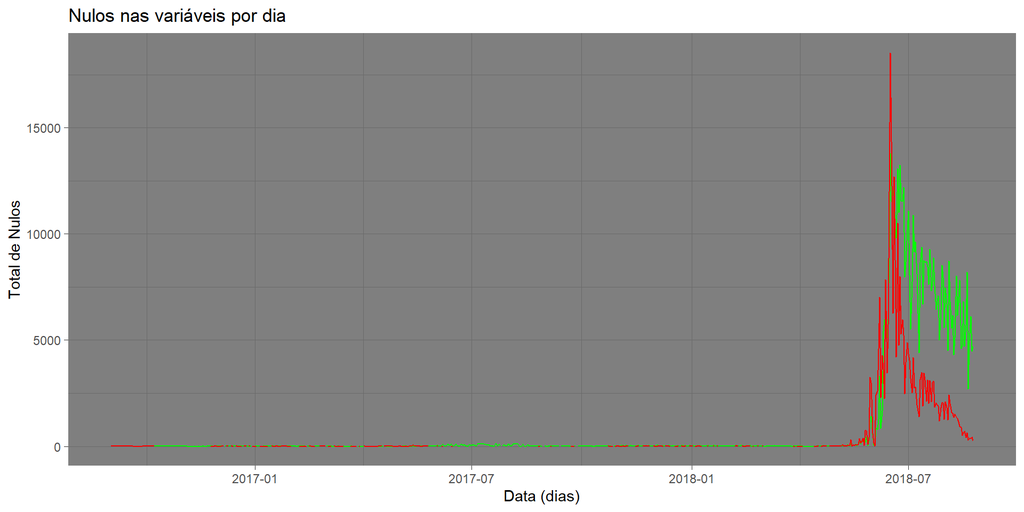

```r
#full

# Gráfico de Full

g_full <- ggplot(full, aes(x=Dia))+
  geom_line(aes(y=Nulls_CAVA_RODA),color="green")+
  geom_line(aes(y=Nulls_ANGULO_FRISO_RODA),color="red")+
  ggtitle("Nulos nas variáveis por dia")+
  xlab("Data (dias)")+
  ylab("Total de Nulos")+
  theme_dark()
g_full
```

Percebe-se um aumento significativo no número de dados núlos no final do período.

###### ANGULO_ATAQUE_EIXO_FRONTAL_TRUQUE, ANGULO_ATAQUE_EIXO_TRASEIRO_TRUQUE, TRACKING_POSITION_EIXO_FRONTAL_TRUQUE, TRACKING_POSITION_EIXO_TRASEIRO_TRUQUE, ROTACAO_EIXO, ALINHAMENTO_ENTRE_EIXOS_(IAM), DESLOCAMENTO_ENTRE_EIXOS_(SHIFT) e TRACKING_ERROR_(TE)

Essas variáveis apresentam 19.723 (1%) de valores nulos

```r
# Avaliando os dados nulos para CAVA_RODA, indentificando se ocorreu alguma data com maior numero de dados nulos.

variaveis <- c("ANGULO_ATAQUE_EIXO_FRONTAL_TRUQUE",
"ANGULO_ATAQUE_EIXO_TRASEIRO_TRUQUE",
"TRACKING_POSITION_EIXO_FRONTAL_TRUQUE",
"TRACKING_POSITION_EIXO_TRASEIRO_TRUQUE",
"ROTACAO_EIXO",
"ALINHAMENTO_ENTRE_EIXOS_IAM",
"DESLOCAMENTO_ENTRE_EIXOS_SHIFT",
"TRACKING_ERROR_TE")

#ANGULO_ATAQUE_EIXO_FRONTAL_TRUQUE
# Avaliando os dados nulos para ANGULO_ATAQUE_EIXO_FRONTAL_TRUQUE, indentificando se ocorreu alguma data com maior numero de dados nulos.

df_null_ANGULO_ATAQUE_EIXO_FRONTAL_TRUQUE <- where(df, isNull(df$ANGULO_ATAQUE_EIXO_FRONTAL_TRUQUE))

nulos_ANGULO_ATAQUE_EIXO_FRONTAL_TRUQUE <- count(df_null_ANGULO_ATAQUE_EIXO_FRONTAL_TRUQUE)

# O percentual de dados faltando para ANGULO_ATAQUE_EIXO_FRONTAL_TRUQUE é de 1%

gb_df_null_ANGULO_ATAQUE_EIXO_FRONTAL_TRUQUE <- groupBy(df_null_ANGULO_ATAQUE_EIXO_FRONTAL_TRUQUE, df_null_ANGULO_ATAQUE_EIXO_FRONTAL_TRUQUE$Dia)

nNull_ANGULO_ATAQUE_EIXO_FRONTAL_TRUQUE_by_DIA <- agg(gb_df_null_ANGULO_ATAQUE_EIXO_FRONTAL_TRUQUE, Nulls_ANGULO_ATAQUE_EIXO_FRONTAL_TRUQUE = n(df_null_ANGULO_ATAQUE_EIXO_FRONTAL_TRUQUE$Dia))

nNull_ANGULO_ATAQUE_EIXO_FRONTAL_TRUQUE_by_DIA.dat <- collect(nNull_ANGULO_ATAQUE_EIXO_FRONTAL_TRUQUE_by_DIA)
#nNull_ANGULO_ATAQUE_EIXO_FRONTAL_TRUQUE_by_DIA.dat

ANGULO_ATAQUE_EIXO_FRONTAL_TRUQUE_order_by_date <- nNull_ANGULO_ATAQUE_EIXO_FRONTAL_TRUQUE_by_DIA.dat[order(nNull_ANGULO_ATAQUE_EIXO_FRONTAL_TRUQUE_by_DIA.dat$Dia),]
#ANGULO_ATAQUE_EIXO_FRONTAL_TRUQUE_order_by_date

# Avaliando os dados nulos para ANGULO_ATAQUE_EIXO_TRASEIRO_TRUQUE, indentificando se ocorreu alguma data com maior numero de dados nulos.

df_null_ANGULO_ATAQUE_EIXO_TRASEIRO_TRUQUE <- where(df, isNull(df$ANGULO_ATAQUE_EIXO_TRASEIRO_TRUQUE))

nulos_ANGULO_ATAQUE_EIXO_TRASEIRO_TRUQUE <- count(df_null_ANGULO_ATAQUE_EIXO_TRASEIRO_TRUQUE)

# O percentual de dados faltando para ANGULO_ATAQUE_EIXO_TRASEIRO_TRUQUE é de 20%

gb_df_null_ANGULO_ATAQUE_EIXO_TRASEIRO_TRUQUE <- groupBy(df_null_ANGULO_ATAQUE_EIXO_TRASEIRO_TRUQUE, df_null_ANGULO_ATAQUE_EIXO_TRASEIRO_TRUQUE$Dia)

nNull_ANGULO_ATAQUE_EIXO_TRASEIRO_TRUQUE_by_DIA <- agg(gb_df_null_ANGULO_ATAQUE_EIXO_TRASEIRO_TRUQUE, Nulls_ANGULO_ATAQUE_EIXO_TRASEIRO_TRUQUE = n(df_null_ANGULO_ATAQUE_EIXO_TRASEIRO_TRUQUE$Dia))

nNull_ANGULO_ATAQUE_EIXO_TRASEIRO_TRUQUE_by_DIA.dat <- collect(nNull_ANGULO_ATAQUE_EIXO_TRASEIRO_TRUQUE_by_DIA)
#nNull_ANGULO_ATAQUE_EIXO_TRASEIRO_TRUQUE_by_DIA.dat

ANGULO_ATAQUE_EIXO_TRASEIRO_TRUQUE_order_by_date <- nNull_ANGULO_ATAQUE_EIXO_TRASEIRO_TRUQUE_by_DIA.dat[order(nNull_ANGULO_ATAQUE_EIXO_TRASEIRO_TRUQUE_by_DIA.dat$Dia),]
#ANGULO_ATAQUE_EIXO_TRASEIRO_TRUQUE_order_by_date

# Avaliando os dados nulos para TRACKING_POSITION_EIXO_FRONTAL_TRUQUE, indentificando se ocorreu alguma data com maior numero de dados nulos.

df_null_TRACKING_POSITION_EIXO_FRONTAL_TRUQUE <- where(df, isNull(df$TRACKING_POSITION_EIXO_FRONTAL_TRUQUE))

# O percentual de dados faltando para TRACKING_POSITION_EIXO_FRONTAL_TRUQUE é de 20%

gb_df_null_TRACKING_POSITION_EIXO_FRONTAL_TRUQUE <- groupBy(df_null_TRACKING_POSITION_EIXO_FRONTAL_TRUQUE, df_null_TRACKING_POSITION_EIXO_FRONTAL_TRUQUE$Dia)

nNull_TRACKING_POSITION_EIXO_FRONTAL_TRUQUE_by_DIA <- agg(gb_df_null_TRACKING_POSITION_EIXO_FRONTAL_TRUQUE, Nulls_TRACKING_POSITION_EIXO_FRONTAL_TRUQUE = n(df_null_TRACKING_POSITION_EIXO_FRONTAL_TRUQUE$Dia))

nNull_TRACKING_POSITION_EIXO_FRONTAL_TRUQUE_by_DIA.dat <- collect(nNull_TRACKING_POSITION_EIXO_FRONTAL_TRUQUE_by_DIA)
#nNull_TRACKING_POSITION_EIXO_FRONTAL_TRUQUE_by_DIA.dat

TRACKING_POSITION_EIXO_FRONTAL_TRUQUE_order_by_date <- nNull_TRACKING_POSITION_EIXO_FRONTAL_TRUQUE_by_DIA.dat[order(nNull_TRACKING_POSITION_EIXO_FRONTAL_TRUQUE_by_DIA.dat$Dia),]
#TRACKING_POSITION_EIXO_FRONTAL_TRUQUE_order_by_date

full <- full_join(ANGULO_ATAQUE_EIXO_FRONTAL_TRUQUE_order_by_date,
                  ANGULO_ATAQUE_EIXO_TRASEIRO_TRUQUE_order_by_date,
                  by = NULL)
full <- full_join(full,
                  TRACKING_POSITION_EIXO_FRONTAL_TRUQUE_order_by_date,
                  by= NULL)
```

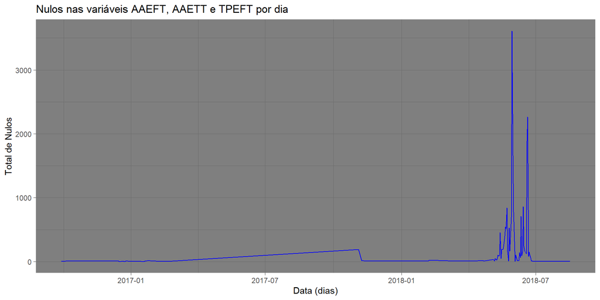

```r
g_full <- ggplot(full, aes(x=Dia))+
  geom_line(aes(y=Nulls_ANGULO_ATAQUE_EIXO_FRONTAL_TRUQUE),color="green")+
  geom_line(aes(y=Nulls_ANGULO_ATAQUE_EIXO_TRASEIRO_TRUQUE),color="red")+
  geom_line(aes(y=Nulls_TRACKING_POSITION_EIXO_FRONTAL_TRUQUE),color="blue")+
  ggtitle("Nulos nas variáveis AAEFT, AAETT e TPEFT por dia")+
  xlab("Data (dias)")+
  ylab("Total de Nulos")+
  theme_dark()
g_full
```

Essas variaveis todas apresentaram um comportamento igual, ou seja, todas os casos nulos ocorreram no mesmo periodo

##### Realizando limpeza dos dados

```r
#Limpando os dados nulos das colunas
#colnames(df)

dim(df)[1] %>% paste("Total de dados da base original ",.,sep="") %>% print()
```

```
## [1] "Total de dados da base original 2966288"
```

```r
# Retirando os dados nulos de CAVA_RODA (20.46% da base)
df_clean <- df %>% where(.,!isNull(.[[17]]))
# Retirando os dados nulos de ANGULO_FRISO_RODA (9.69% da base)
df_clean <- df_clean %>% where(.,!isNull(.[[14]]))
# Retirando os dados nulos de ESPESSURA_FRISO_RODA (0.05% da base)
df_clean <- df_clean %>% where(.,!isNull(.[[16]]))
# Retirando os dados nulos de ALTURA_FRISO_RODA (0.01% da base)
df_clean <- df_clean %>% where(.,!isNull(.[[15]]))
# Retirando os dados nulos de TRACKING_ERROR_(TE) (0.21% da base)
df_clean <- df_clean %>% where(.,!isNull(.[[25]]))

dim(df_clean)[1] %>% paste("Total de dados da base limpa ",.,sep="") %>% print()
```

```
## [1] "Total de dados da base limpa 2145868"
```

```r
# Redução dos dados
reduc <- round(((dim(df_clean)[1]/dim(df)[1])-1)*100,2)
reduc <- paste("Redução dos dados de ",-reduc,"%",sep="")
print(reduc)
```

```
## [1] "Redução dos dados de 27.66%"
```

```r
# Criando a coluna de tipo de dados
for (i in 1:length(colnames(df_clean))){
  x[i] <- dtypes(df_clean)[[i]][1]
  Tipo_de_dados[i] <- dtypes(df_clean)[[i]][2]
}
tipo_dados <- as.data.frame(Tipo_de_dados,x)

cont_clean <- data.frame()
for (coluna in colnames(df_clean)){

    cont_clean[coluna,"Nulo"]  <- ifelse(is.numeric(test_null(df_clean,coluna)),test_null(df_clean,coluna),0)
  cont_clean[coluna,"% Nulo"]  <- ifelse(is.numeric(test_null(df_clean,coluna)),
                                        paste(round(((test_null(df_clean,coluna)/total)*100),2),"%",sep=""),
                                        "0%")
  cont_clean[coluna,"isNAN"] <-    ifelse(is.numeric(test_isNAN(df_clean,coluna)),test_isNAN(df_clean,coluna),0)
  cont_clean[coluna,"% isNAN"]  <- ifelse(is.numeric(test_isNAN(df_clean,coluna)),
                                        paste(round(((test_isNAN(df_clean,coluna)/total)*100),2),"%",sep=""),
                                        "0%")
  cont_clean[coluna,"Vazio"] <- ifelse(is.numeric(test_vazio(df_clean,coluna)),test_vazio(df_clean,coluna),0)
  cont_clean[coluna,"% Vazio"]  <- ifelse(is.numeric(test_vazio(df_clean,coluna)),
                                        paste(round(((test_vazio(df_clean,coluna)/total)*100),2),"%",sep=""),
                                        "0%")
  cont_clean[coluna,"Zero"]  <- ifelse(is.numeric(test_zero(df_clean,coluna)),test_zero(df_clean,coluna),0)
  cont_clean[coluna,"% Zero"]  <- ifelse(is.numeric(test_zero(df_clean,coluna)),
                                        paste(round(((test_zero(df_clean,coluna)/total)*100),2),"%",sep=""),
                                        "0%")
}

cont_clean <- cbind(cont_clean,tipo_dados)

cont_clean %>% kable(., format = "html",row.names = T, digits = 2) %>%
  kable_styling(bootstrap_options = c("striped","hover","condensed","responsive"))
```

|  | Nulo | % Nulo | isNAN | % isNAN | Vazio | % Vazio | Zero | % Zero | Tipo_de_dados |
| --- | --- | --- | --- | --- | --- | --- | --- | --- | --- |
| ROW_ID | 0 | 0% | 0 | 0% | 0 | 0% | 0 | 0% | string |
| DATA_HORA_LEITURA | 0 | 0% | 0 | 0% | 0 | 0% | 0 | 0% | timestamp |
| CODIGO_VAGAO | 0 | 0% | 0 | 0% | 0 | 0% | 0 | 0% | string |
| CODIGO_RODEIRO | 0 | 0% | 0 | 0% | 0 | 0% | 0 | 0% | string |
| CODIGO_RODA | 0 | 0% | 0 | 0% | 0 | 0% | 0 | 0% | string |
| LADO_RODA | 0 | 0% | 0 | 0% | 0 | 0% | 0 | 0% | string |
| EIXO_VAGAO | 0 | 0% | 0 | 0% | 0 | 0% | 0 | 0% | double |
| CICLO_RODEIRO | 0 | 0% | 0 | 0% | 0 | 0% | 0 | 0% | string |
| TRAIN_ID | 0 | 0% | 0 | 0% | 0 | 0% | 0 | 0% | string |
| SENTIDO_TREM | 0 | 0% | 0 | 0% | 0 | 0% | 0 | 0% | string |
| VELOCIDADE_ENTRADA_TREM | 0 | 0% | 0 | 0% | 0 | 0% | 0 | 0% | double |
| VELOCIDADE_SAIDA_TREM | 0 | 0% | 0 | 0% | 0 | 0% | 0 | 0% | double |
| POSICAO_VAGAO_COMPOSICAO | 0 | 0% | 0 | 0% | 0 | 0% | 0 | 0% | double |
| ANGULO_FRISO_RODA | 0 | 0% | 0 | 0% | 0 | 0% | 0 | 0% | double |
| ALTURA_FRISO_RODA | 0 | 0% | 0 | 0% | 0 | 0% | 0 | 0% | double |
| ESPESSURA_FRISO_RODA | 0 | 0% | 0 | 0% | 0 | 0% | 0 | 0% | double |
| CAVA_RODA | 0 | 0% | 0 | 0% | 0 | 0% | 236 | 0.01% | double |
| ANGULO_ATAQUE_EIXO_FRONTAL_TRUQUE | 0 | 0% | 0 | 0% | 0 | 0% | 288355 | 9.72% | double |
| ANGULO_ATAQUE_EIXO_TRASEIRO_TRUQUE | 0 | 0% | 0 | 0% | 0 | 0% | 310400 | 10.46% | double |
| TRACKING_POSITION_EIXO_FRONTAL_TRUQUE | 0 | 0% | 0 | 0% | 0 | 0% | 11346 | 0.38% | double |
| TRACKING_POSITION_EIXO_TRASEIRO_TRUQUE | 0 | 0% | 0 | 0% | 0 | 0% | 13779 | 0.46% | double |
| ROTACAO_EIXO | 0 | 0% | 0 | 0% | 0 | 0% | 2145665 | 72.34% | double |
| ALINHAMENTO_ENTRE_EIXOS_(IAM) | 0 | 0% | 0 | 0% | 0 | 0% | 221414 | 7.46% | double |
| DESLOCAMENTO_ENTRE_EIXOS_(SHIFT) | 0 | 0% | 0 | 0% | 0 | 0% | 844836 | 28.48% | double |
| TRACKING_ERROR_(TE) | 0 | 0% | 0 | 0% | 0 | 0% | 11964 | 0.4% | double |
| SERPENTEAMENTO_(HUNTING) | 0 | 0% | 0 | 0% | 0 | 0% | 2145868 | 72.34% | double |
| friso_baixo | 0 | 0% | 0 | 0% | 0 | 0% | 2121955 | 71.54% | double |
| Dia | 0 | 0% | 0 | 0% | 0 | 0% | 0 | 0% | date |

#### Identificar as principais estatisticas da Amostra

```r
sumstats1 <- describe(df, "EIXO_VAGAO",
                     "VELOCIDADE_ENTRADA_TREM",
                     "VELOCIDADE_SAIDA_TREM")
sumstats2 <- describe(df, "POSICAO_VAGAO_COMPOSICAO",
                     "ANGULO_FRISO_RODA",
                     "ALTURA_FRISO_RODA")
sumstats3 <- describe(df, "ESPESSURA_FRISO_RODA",
                     "CAVA_RODA",
                     "ROTACAO_EIXO")
sumstats4 <- describe(df, "ANGULO_ATAQUE_EIXO_FRONTAL_TRUQUE",
                     "ANGULO_ATAQUE_EIXO_TRASEIRO_TRUQUE")
sumstats5 <- describe(df, "TRACKING_POSITION_EIXO_FRONTAL_TRUQUE")
sumstats6 <- describe(df, "TRACKING_POSITION_EIXO_TRASEIRO_TRUQUE")
showDF(sumstats1)
```

```
## +-------+------------------+-----------------------+---------------------+
## |summary|        EIXO_VAGAO|VELOCIDADE_ENTRADA_TREM|VELOCIDADE_SAIDA_TREM|
## +-------+------------------+-----------------------+---------------------+
## |  count|           2966288|                2966288|              2966288|
## |   mean| 2.499992246201313|     45.851930089054065|    31.63178760794636|
## | stddev|1.1180869438333527|      8.842785766732014|    5.349229414227436|
## |    min|               1.0|                   15.0|                 14.0|
## |    max|               6.0|                   69.0|                 63.0|
## +-------+------------------+-----------------------+---------------------+
```

```r
showDF(sumstats2)
```

```
## +-------+------------------------+------------------+------------------+
## |summary|POSICAO_VAGAO_COMPOSICAO| ANGULO_FRISO_RODA| ALTURA_FRISO_RODA|
## +-------+------------------------+------------------+------------------+
## |  count|                 2966288|           2678880|           2963934|
## |   mean|      163.28691077872412|62.052009147757126|30.277685014118106|
## | stddev|       95.29191031459632|3.7897877072763655|1.6706879018271459|
## |    min|                     1.0|              55.0|              25.0|
## |    max|                   334.0|              90.0|  43.7999992370605|
## +-------+------------------------+------------------+------------------+
```

```r
showDF(sumstats3)
```

```
## +-------+--------------------+------------------+--------------------+
## |summary|ESPESSURA_FRISO_RODA|         CAVA_RODA|        ROTACAO_EIXO|
## +-------+--------------------+------------------+--------------------+
## |  count|             2955142|           2359239|             2946565|
## |   mean|   31.07418397401171|0.8209637185041189|1.379911852146956E-4|
## | stddev|   2.579244224133342|0.6680407302425816| 0.01567733191380352|
## |    min|    18.7800006866455|               0.0|   -1.63333332538605|
## |    max|                38.0|  8.05000019073486|    2.55000019073486|
## +-------+--------------------+------------------+--------------------+
```

```r
showDF(sumstats4)
```

```
## +-------+---------------------------------+----------------------------------+
## |summary|ANGULO_ATAQUE_EIXO_FRONTAL_TRUQUE|ANGULO_ATAQUE_EIXO_TRASEIRO_TRUQUE|
## +-------+---------------------------------+----------------------------------+
## |  count|                          2946565|                           2946565|
## |   mean|             -0.04289363034249575|               -0.0236071532843643|
## | stddev|              0.27004508443638253|                0.2444538960506514|
## |    min|                -5.09999990463257|                 -3.29999995231628|
## |    max|                 6.09999990463257|                             3.633|
## +-------+---------------------------------+----------------------------------+
```

```r
showDF(sumstats5)
```

```
## +-------+-------------------------------------+
## |summary|TRACKING_POSITION_EIXO_FRONTAL_TRUQUE|
## +-------+-------------------------------------+
## |  count|                              2946565|
## |   mean|                   0.5022502609386084|
## | stddev|                    5.726904584855679|
## |    min|                    -23.9000015258789|
## |    max|                                 23.5|
## +-------+-------------------------------------+
```

```r
showDF(sumstats6)
```

```
## +-------+--------------------------------------+
## |summary|TRACKING_POSITION_EIXO_TRASEIRO_TRUQUE|
## +-------+--------------------------------------+
## |  count|                               2946565|
## |   mean|                   0.11060103707279409|
## | stddev|                     5.023530460867575|
## |    min|                     -24.7000007629395|
## |    max|                      23.6000003814697|
## +-------+--------------------------------------+
```

```
##   velo_entrada_avg
## 1         45.85193
```

```
##   velo_entrada_sd
## 1        8.842786
```

```
##   velo_entrada_var
## 1         78.19486
```

```
##   velo_entrada_max
## 1               69
```

[output not shown]

```
##   alt_friso_sd
## 1     2.579244
```

```
##   alt_friso_var
## 1      6.652501
```

```
##   alt_friso_max
## 1            38
```

```
##    CODIGO_RODA friso_avg count
## 1 0569561RIGHT   35.3795    20
## 2  0570064LEFT   36.1660    20
## 3 0833412RIGHT   31.8750    20
## 4  0836602LEFT   29.4280    20
## 5  5287853LEFT   31.7345    20
## 6  5288151LEFT   32.9110    20
```

#### Identificar as principais correlações entre os dados

```r
# Medindo a correlação entre ESPESSURA FRISO RODA E EIXO VAGAO
corr_EFR_EV <- corr(df, "ESPESSURA_FRISO_RODA", "EIXO_VAGAO")
corr_EFR_EV
```

```
## [1] 0.03050354
```

#### Construir visualizações

Listados com top 10

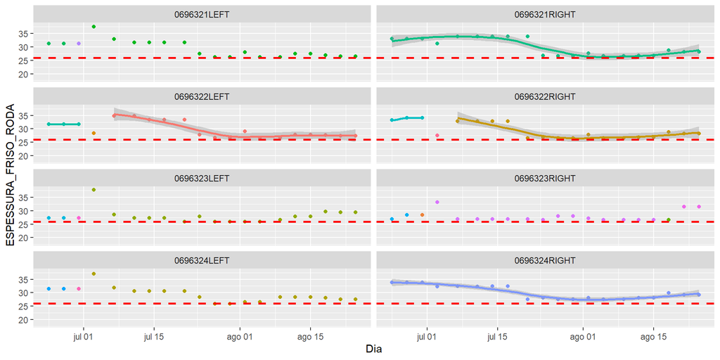

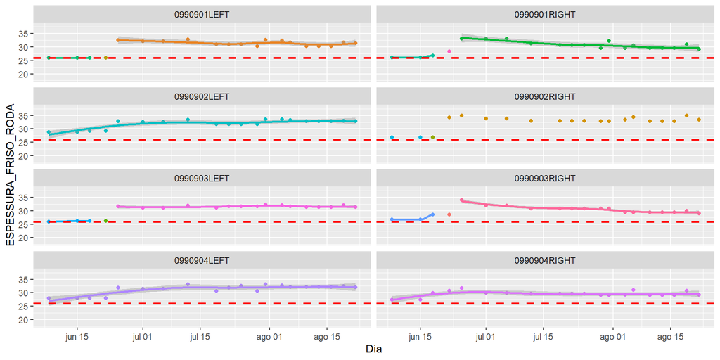

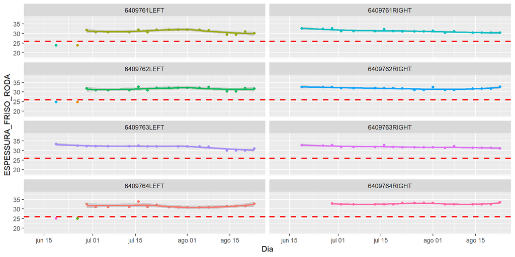

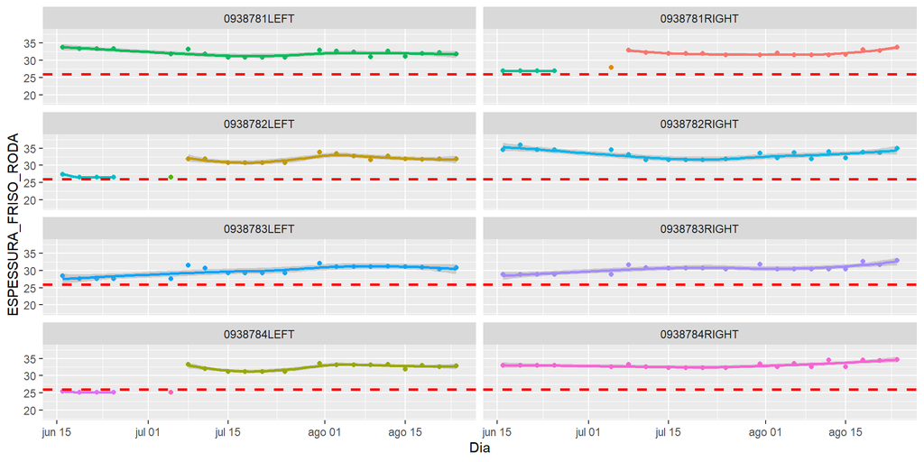

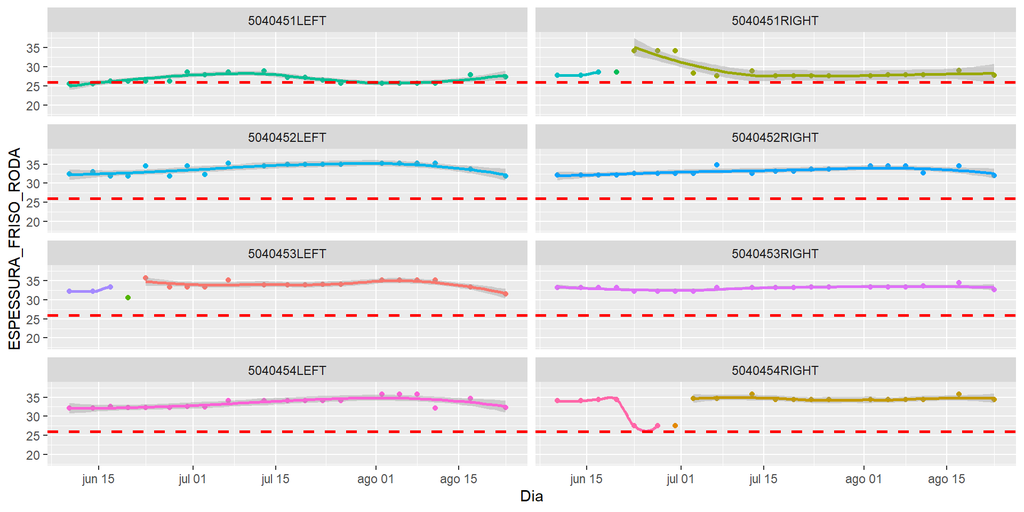

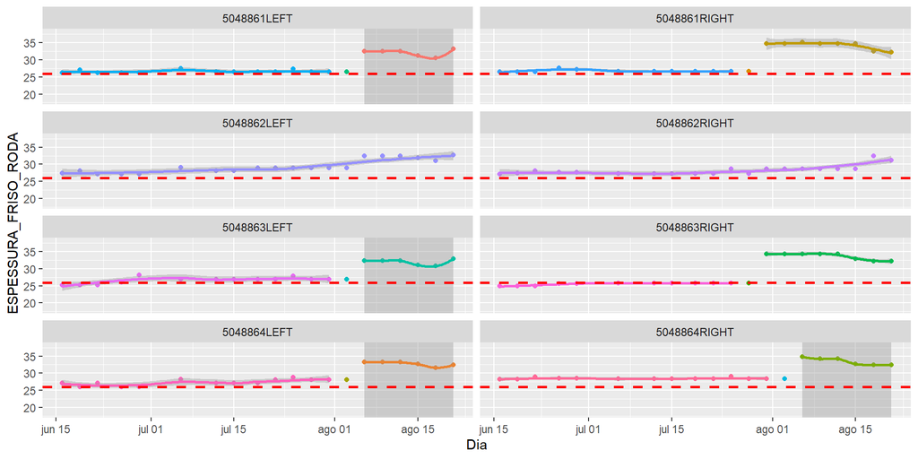

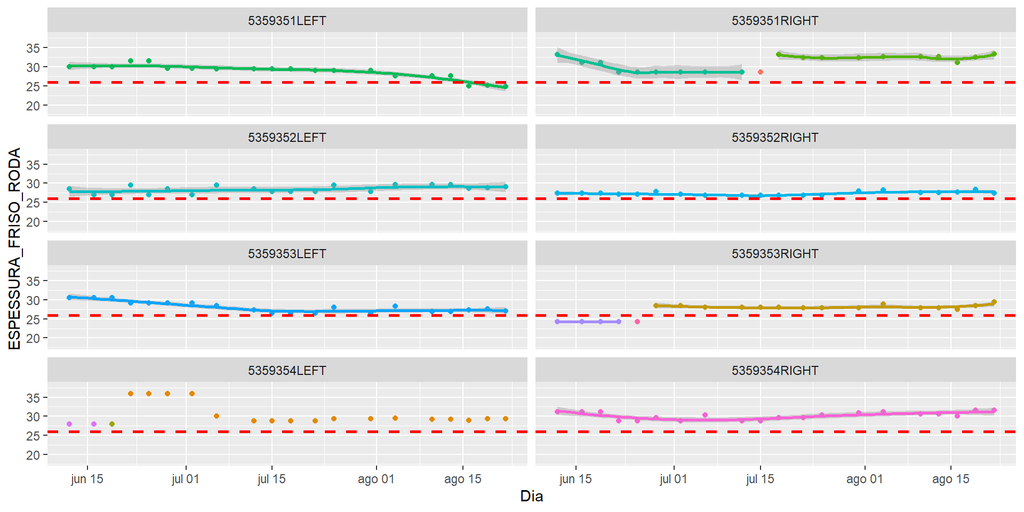

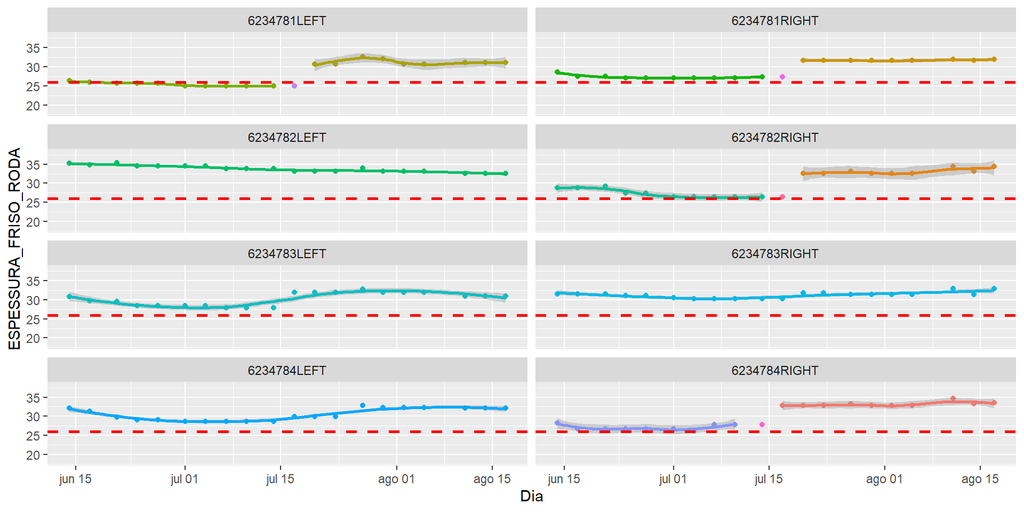

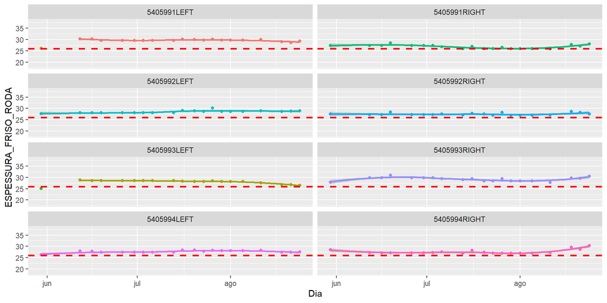

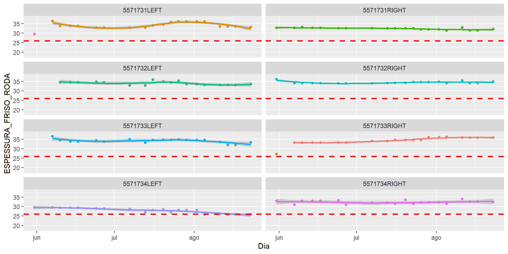

```r
createOrReplaceTempView(df, "tabela")

sdf_vagao_trocas_roda <- sql("select
    CODIGO_VAGAO
    ,count(*) qtd

    from tabela
    where CODIGO_RODA != CICLO_RODEIRO
          and
          CODIGO_VAGAO in
              (select
                  CODIGO_VAGAO
                      from tabela
                    where friso_baixo ==1
                    group by CODIGO_VAGAO)

    group by CODIGO_VAGAO
    order by qtd desc

    "

    )



sdf_vagao_trocas_roda_all <- sql(
"
  select
    *
  from
  tabela

  where CODIGO_VAGAO in
  (
  select
    CODIGO_VAGAO

      from tabela
    where CODIGO_RODA != CICLO_RODEIRO
          and
          CODIGO_VAGAO in
              (select
                  CODIGO_VAGAO
                      from tabela
                    where friso_baixo ==1
                    group by CODIGO_VAGAO)

    group by CODIGO_VAGAO
  )

  "
)






lista_vagoes_troca_friso_baixo <- sdf_vagao_trocas_roda %>% head(1000)


vagoes <- lista_vagoes_troca_friso_baixo %>% head(10) %>% as.list()

myplots <- list()
n <- 1
for (vagao in vagoes$CODIGO_VAGAO){
  filtro_vagao <- vagao
  g1 <-
    where(df,df$CODIGO_VAGAO==filtro_vagao)  %>%
    head(10000) %>%
    ggplot(aes(x=Dia, y=ESPESSURA_FRISO_RODA,color=CICLO_RODEIRO))+
    geom_point()+facet_wrap(~CODIGO_RODA,ncol = 2)+
    scale_y_continuous(limits = c(18,38))+
    geom_smooth()+
    geom_hline(yintercept=26, linetype="dashed", color = "red", size=1)+
    theme(legend.position="none")

  myplots[[n]] <- g1
  n <- n+1
  print(g1)
}
```

```r
# where(df,df$CODIGO_VAGAO=='69632')%>%
#   collect(.)%>%
#   ggplot(aes(x=Dia, y=ESPESSURA_FRISO_RODA,color=CICLO_RODEIRO))+
#   geom_point()+facet_wrap(~CODIGO_RODA,ncol = 2)+
#   scale_y_continuous(limits = c(18,38))+
#   geom_smooth()+
#   geom_hline(yintercept=26, linetype="dashed", color = "red", size=1)+
#     theme(legend.position="none")
```

Listados com bottom 10

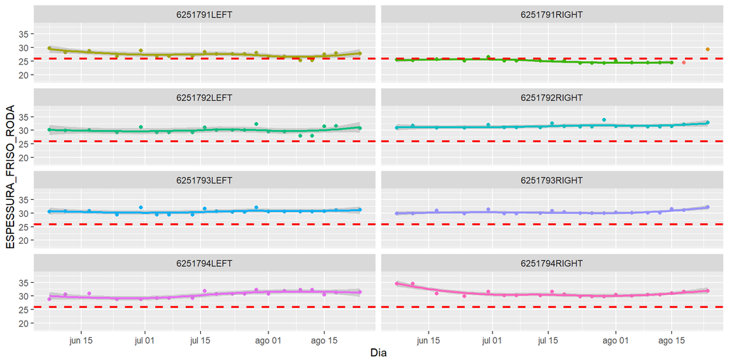

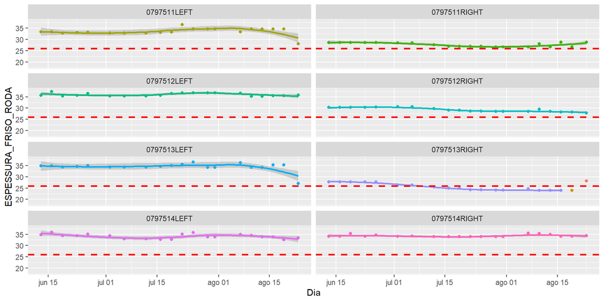

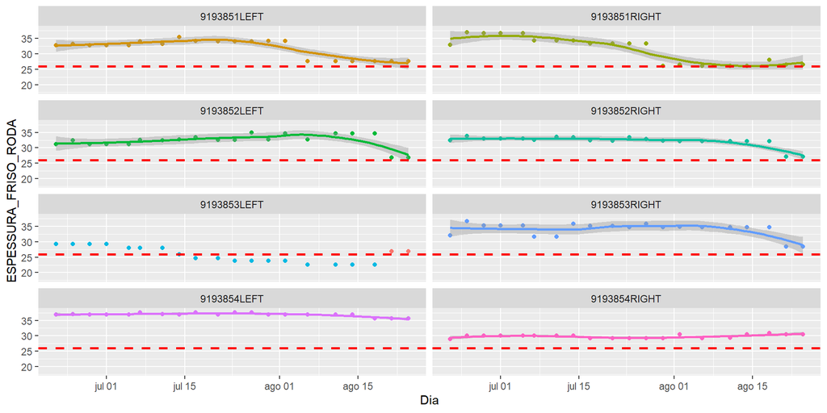

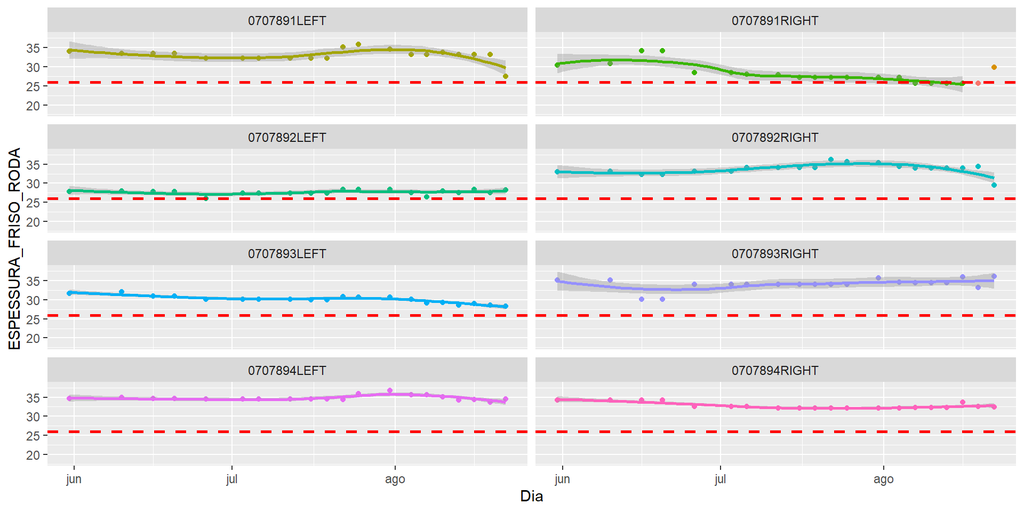

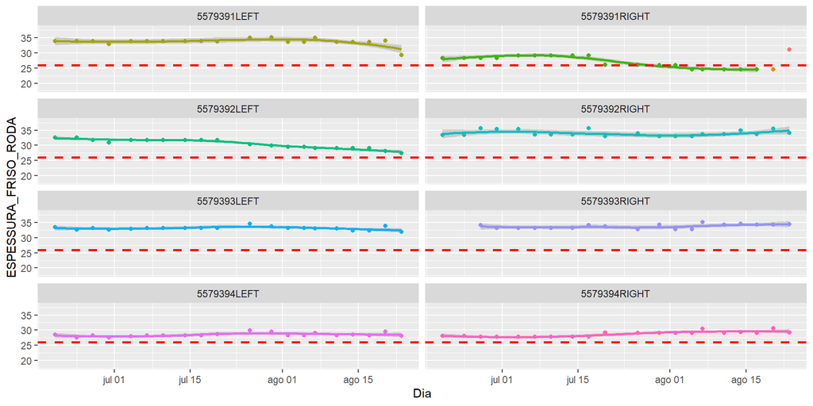

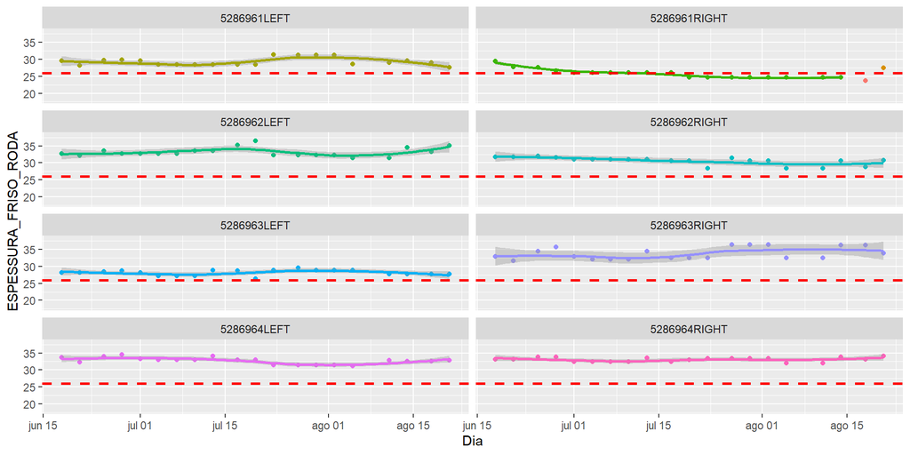

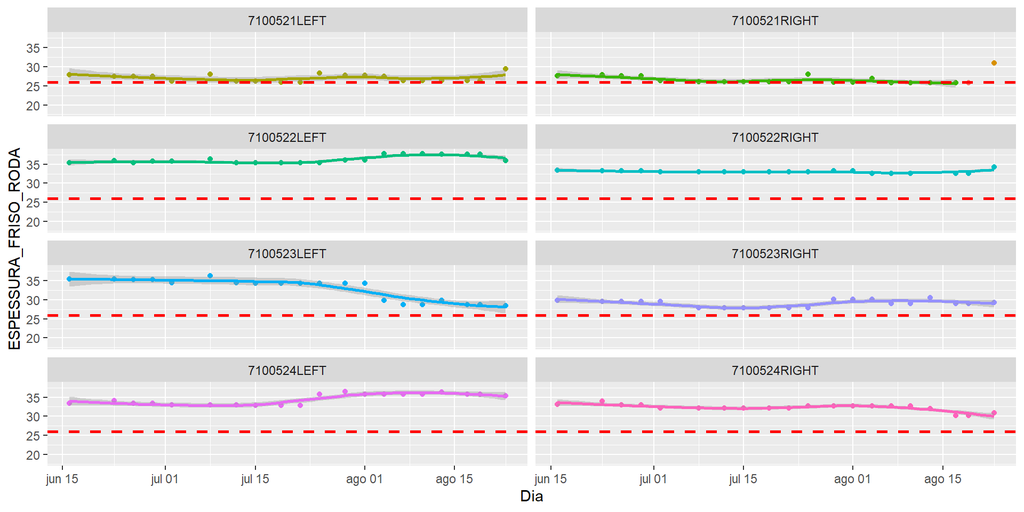

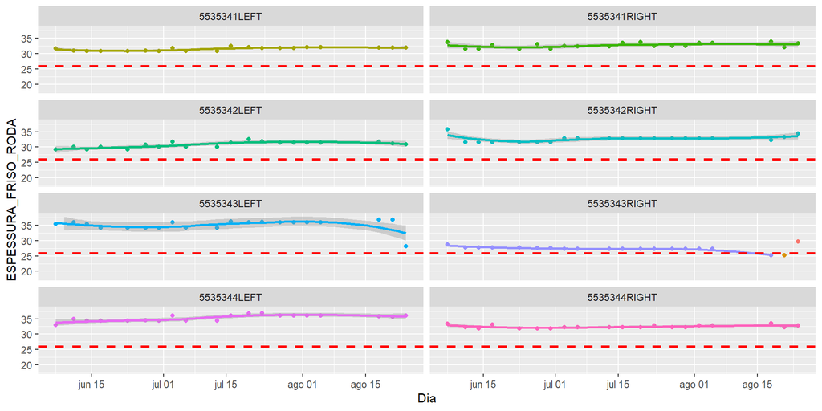

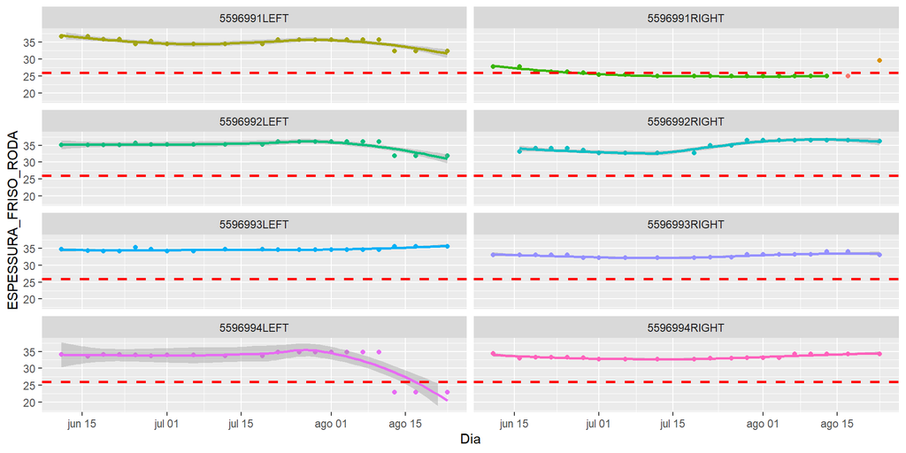

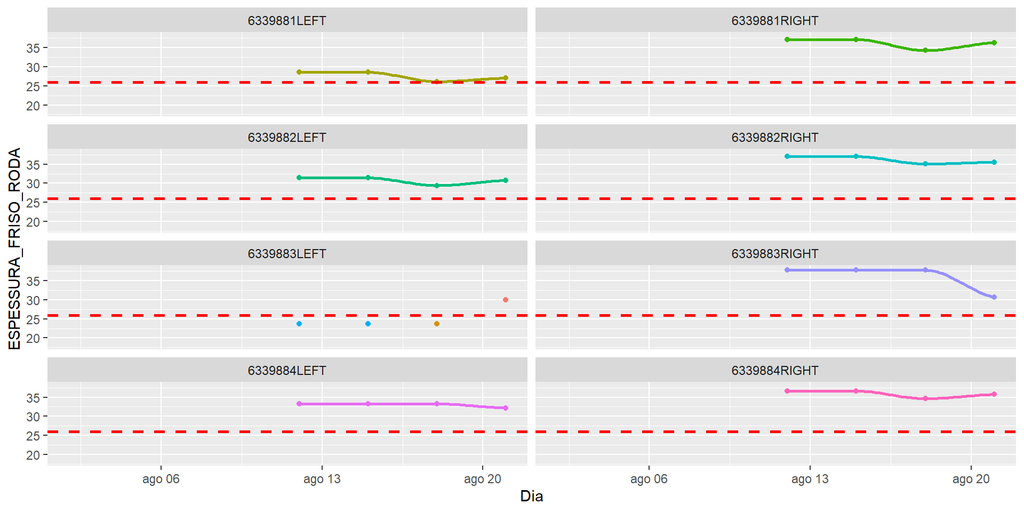

```r
vagoes <- lista_vagoes_troca_friso_baixo %>% tail(10) %>% as.list()

myplots <- list()
n <- 1
for (vagao in vagoes$CODIGO_VAGAO){
  filtro_vagao <- vagao
  g1 <-
    where(df,df$CODIGO_VAGAO==filtro_vagao)  %>%
    head(10000) %>%
    ggplot(aes(x=Dia, y=ESPESSURA_FRISO_RODA,color=CICLO_RODEIRO))+
    geom_point()+facet_wrap(~CODIGO_RODA,ncol = 2)+
    scale_y_continuous(limits = c(18,38))+
    geom_smooth()+
    geom_hline(yintercept=26, linetype="dashed", color = "red", size=1)+
    theme(legend.position="none")

  myplots[[n]] <- g1
  n <- n+1
  print(g1)
}
```

```r
#Guilherme
```

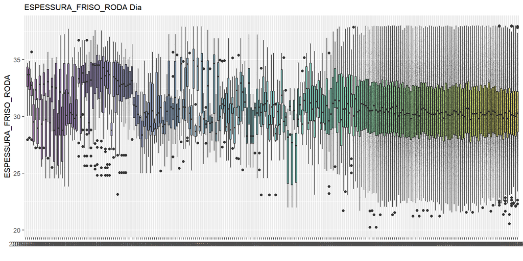

```r
#sdf_RODEIRO_friso_baixo_all  %>%
#where(df,df$CODIGO_VAGAO=='515276') %>%

sdf_vagao_trocas_roda_all %>%
 collect(.) %>%
 ggplot( aes(x=as.character(Dia), y=ESPESSURA_FRISO_RODA, fill=as.character(Dia))) +
   geom_boxplot() +
   scale_fill_viridis(discrete = TRUE, alpha=0.6) +
   geom_jitter(color="black", size=0.05, alpha=0.05) +
   theme(
     legend.position="none",
     plot.title = element_text(size=11)
   ) +
   #scale_y_continuous(limits = c(0,100))+
   ggtitle("ESPESSURA_FRISO_RODA Dia") +
   xlab("")
```

### Preparação dos Dados

```r
df_sample %>% where(.,isNull(.[["ANGULO_FRISO_RODA"]]))%>% head(100)
```

```
##          ROW_ID   DATA_HORA_LEITURA CODIGO_VAGAO CODIGO_RODEIRO  CODIGO_RODA
## 1    1562399671 2018-06-15 05:26:58       603281        6032812 6032812RIGHT
## 2    -363114070 2018-06-18 07:49:04       631071        6310712 6310712RIGHT
## 3   -1665841206 2018-08-01 21:07:39       614070        6140701 6140701RIGHT
## 4     924140842 2018-06-22 13:02:02       551825        5518254 5518254RIGHT
## 5     608832371 2018-06-09 07:29:19       536826        5368264 5368264RIGHT
## 6   -1496772488 2018-06-25 20:02:32        64967         649674 0649674RIGHT
## 7   -1512407846 2018-07-30 16:00:48        89404         894042 0894042RIGHT
## 8      29465920 2018-07-12 15:56:50        96320         963203 0963203RIGHT
## 9   -1637407761 2018-07-03 08:30:48       501704        5017042  5017042LEFT
## 10   1347709615 2018-06-09 10:19:35       547038        5470382 5470382RIGHT
## 11   -690139281 2018-07-16 08:19:18       535595        5355954 5355954RIGHT
## 12   -785786310 2018-06-17 06:50:26       526961        5269612 5269612RIGHT
## 13    817304492 2018-07-25 19:31:21       531352        5313521 5313521RIGHT
## 14    962536792 2018-06-23 08:12:37       601440        6014403 6014403RIGHT
```

[output cut: 894 more lines]

```r
df_sample %>% where(.,!isNull(.[["ANGULO_FRISO_RODA"]]))%>% head(100)
```

```
##          ROW_ID   DATA_HORA_LEITURA CODIGO_VAGAO CODIGO_RODEIRO  CODIGO_RODA
## 1     985985705 2018-08-23 21:35:04       558820        5588202 5588202RIGHT
## 2    1892695630 2018-07-21 21:04:48       555154        5551543 5551543RIGHT
## 3    1897227837 2018-08-03 02:01:56       635425        6354252  6354252LEFT
## 4    1080337551 2018-07-25 16:20:33       713167        7131674  7131674LEFT
## 5   -1611644036 2018-07-25 02:31:38       505238        5052381 5052381RIGHT
## 6   -1524370395 2018-08-09 13:54:13       505238        5052381 5052381RIGHT
## 7   -1070207178 2018-08-08 20:05:31       638980        6389804 6389804RIGHT
## 8    1961752015 2018-07-28 06:59:21       635565        6355651 6355651RIGHT
## 9     -35737787 2018-08-17 10:49:31       921576        9215762  9215762LEFT
## 10    483691099 2018-08-23 01:27:52       519000        5190001 5190001RIGHT
## 11   1238368812 2018-08-23 17:21:56       629441        6294414  6294414LEFT
## 12   -121047150 2018-07-03 07:20:37       920383        9203832  9203832LEFT
## 13   -996675003 2018-07-18 19:11:21       601601        6016011 6016011RIGHT
## 14   1023861969 2018-06-24 05:39:28       637622        6376223  6376223LEFT
```

[output cut: 894 more lines]

```r
grupo_angulo_null <- groupBy(df %>% where(.,isNull(.[["ANGULO_FRISO_RODA"]])), df$CODIGO_RODA)
df2 <- agg(grupo_angulo_null,count = n(df$CODIGO_RODA))
df2 %>% head(1000)
```

```
##       CODIGO_RODA count
## 1    0569561RIGHT    11
## 2    5431212RIGHT    14
## 3    5012672RIGHT     1
## 4    6241133RIGHT     6
## 5    5514771RIGHT     3
## 6    9132393RIGHT     4
## 7    5329282RIGHT    14
## 8    6165441RIGHT     1
## 9    9112364RIGHT     2
## 10    5330613LEFT     3
## 11    6165792LEFT     1
## 12   9113921RIGHT     6
## 13    0660211LEFT     1
## 14    0663821LEFT     1
```

[output cut: 986 more lines]

```r
#Algumas rodas nunca tiveram medidas de ângulo
#(5054164RIGHT,0960614RIGHT,6083714RIGHT,0995294RIGHT,5534531LEFT,5519574RIGHT,0867584RIGHT,6346311RIGHT,0809114RIGHT,5599823RIGHT)
# O que fazer nestes casos?


#Exemplo de rodas com falta de dados e uma opção de completar com fill.

cbind(
df %>%
  where(.,df$CODIGO_RODA %in%
c('0956094RIGHT','6241133RIGHT','0851232RIGHT','7011773RIGHT','0825071RIGHT','5519574RIGHT','5392051LEFT','6395011LEFT','9126664LEFT')) %>%
  select('Dia','CODIGO_RODA','ANGULO_FRISO_RODA') %>%
  arrange('CODIGO_RODA','Dia') %>%
  head(10000)
,

df %>%
  where(.,df$CODIGO_RODA %in%
c('0956094RIGHT','6241133RIGHT','0851232RIGHT','7011773RIGHT','0825071RIGHT','5519574RIGHT','5392051LEFT','6395011LEFT','9126664LEFT')) %>%
  arrange('CODIGO_RODA','Dia') %>%
    select('ANGULO_FRISO_RODA') %>%
  withColumnRenamed('ANGULO_FRISO_RODA','downup') %>%
  head(10000) %>%
  fill('downup', .direction = "downup")

,

df %>%
  where(.,df$CODIGO_RODA %in%
c('0956094RIGHT','6241133RIGHT','0851232RIGHT','7011773RIGHT','0825071RIGHT','5519574RIGHT','5392051LEFT','6395011LEFT','9126664LEFT')) %>%
  arrange('CODIGO_RODA','Dia') %>%
    select('ANGULO_FRISO_RODA') %>%
  withColumnRenamed('ANGULO_FRISO_RODA','up') %>%
  head(10000) %>%
  fill('up', .direction = "up")



,

df %>%
  where(.,df$CODIGO_RODA %in%
c('0956094RIGHT','6241133RIGHT','0851232RIGHT','7011773RIGHT','0825071RIGHT','5519574RIGHT','5392051LEFT','6395011LEFT','9126664LEFT')) %>%
  arrange('CODIGO_RODA','Dia') %>%
    select('ANGULO_FRISO_RODA') %>%
  withColumnRenamed('ANGULO_FRISO_RODA','down') %>%
  head(10000) %>%
  fill('down', .direction = "down")


)
```

```
##            Dia  CODIGO_RODA ANGULO_FRISO_RODA downup     up   down
## 1   2018-06-16 0825071RIGHT                NA 61.678 61.678     NA
## 2   2018-06-19 0825071RIGHT                NA 61.678 61.678     NA
## 3   2018-06-22 0825071RIGHT                NA 61.678 61.678     NA
## 4   2018-06-25 0825071RIGHT                NA 61.678 61.678     NA
## 5   2018-06-29 0825071RIGHT                NA 61.678 61.678     NA
## 6   2018-07-02 0825071RIGHT                NA 61.678 61.678     NA
## 7   2018-07-11 0825071RIGHT                NA 61.678 61.678     NA
## 8   2018-07-14 0825071RIGHT                NA 61.678 61.678     NA
## 9   2018-07-17 0825071RIGHT                NA 61.678 61.678     NA
## 10  2018-07-21 0825071RIGHT                NA 61.678 61.678     NA
## 11  2018-07-24 0825071RIGHT                NA 61.678 61.678     NA
## 12  2018-07-27 0825071RIGHT                NA 61.678 61.678     NA
## 13  2018-07-30 0825071RIGHT                NA 61.678 61.678     NA
## 14  2018-08-02 0825071RIGHT                NA 61.678 61.678     NA
```

[output cut: 166 more lines]

```r
df_sample %>% where(.,isNull(.[["ALTURA_FRISO_RODA"]]))%>% head(100)
```

```
##       ROW_ID   DATA_HORA_LEITURA CODIGO_VAGAO CODIGO_RODEIRO CODIGO_RODA
## 1 1132186704 2018-08-05 16:58:24       638955        6389553 6389553LEFT
##   LADO_RODA EIXO_VAGAO CICLO_RODEIRO  TRAIN_ID SENTIDO_TREM
## 1      LEFT          3   6389553LEFT 25B672CB0          SLZ
##   VELOCIDADE_ENTRADA_TREM VELOCIDADE_SAIDA_TREM POSICAO_VAGAO_COMPOSICAO
## 1                      36                    26                      305
##   ANGULO_FRISO_RODA ALTURA_FRISO_RODA ESPESSURA_FRISO_RODA CAVA_RODA
## 1                NA                NA                   NA        NA
##   ANGULO_ATAQUE_EIXO_FRONTAL_TRUQUE ANGULO_ATAQUE_EIXO_TRASEIRO_TRUQUE
## 1                              -0.3                                  0
##   TRACKING_POSITION_EIXO_FRONTAL_TRUQUE TRACKING_POSITION_EIXO_TRASEIRO_TRUQUE
## 1                                  -6.1                                   -1.1
##   ROTACAO_EIXO ALINHAMENTO_ENTRE_EIXOS_(IAM) DESLOCAMENTO_ENTRE_EIXOS_(SHIFT)
## 1            0                          -0.3                             -3.4
##   TRACKING_ERROR_(TE) SERPENTEAMENTO_(HUNTING) friso_baixo        Dia
## 1                  -5                        0           0 2018-08-05
```

```r
df_sample %>% where(.,isNull(.[["ESPESSURA_FRISO_RODA"]]))%>% head(100)
```

```
##       ROW_ID   DATA_HORA_LEITURA CODIGO_VAGAO CODIGO_RODEIRO  CODIGO_RODA
## 1  534376903 2018-06-16 00:39:49       533291        5332911 5332911RIGHT
## 2 1132186704 2018-08-05 16:58:24       638955        6389553  6389553LEFT
## 3 1782424525 2018-05-31 16:48:30       508377        5083774  5083774LEFT
## 4 1988569141 2018-06-16 23:28:53       603540        6035401 6035401RIGHT
## 5 1517729429 2018-06-13 10:28:01        95188         951882 0951882RIGHT
##   LADO_RODA EIXO_VAGAO CICLO_RODEIRO  TRAIN_ID SENTIDO_TREM
## 1     RIGHT          1  5332911RIGHT 25B245C55          SLZ
## 2      LEFT          3   6389553LEFT 25B672CB0          SLZ
## 3      LEFT          4   5083774LEFT 25B10275E          SLZ
## 4     RIGHT          1  6035401RIGHT 25B259D35          SLZ
## 5     RIGHT          2  0951882RIGHT 25B20F1B1          SLZ
##   VELOCIDADE_ENTRADA_TREM VELOCIDADE_SAIDA_TREM POSICAO_VAGAO_COMPOSICAO
## 1                      35                    30                        7
## 2                      36                    26                      305
```

[output cut: 33 more lines]

```r
df_sample %>% where(.,isNull(.[["CAVA_RODA"]]))%>% head(100)
```

```
##          ROW_ID   DATA_HORA_LEITURA CODIGO_VAGAO CODIGO_RODEIRO  CODIGO_RODA
## 1   -1070207178 2018-08-08 20:05:31       638980        6389804 6389804RIGHT
## 2    1023861969 2018-06-24 05:39:28       637622        6376223  6376223LEFT
## 3    2108625116 2018-07-10 23:16:50       915495        9154954  9154954LEFT
## 4     332638739 2018-07-12 03:56:28       615904        6159041 6159041RIGHT
## 5     956591816 2018-07-17 12:25:33       504011        5040112 5040112RIGHT
## 6   -1665841206 2018-08-01 21:07:39       614070        6140701 6140701RIGHT
## 7    -210317533 2018-06-30 08:19:11       640933        6409332  6409332LEFT
## 8     681453432 2018-06-22 04:32:06       620029        6200291  6200291LEFT
## 9    -751967402 2018-07-28 17:48:20       903250        9032502 9032502RIGHT
## 10  -1660475885 2018-07-29 11:00:06       541234        5412343  5412343LEFT
## 11  -1960362557 2018-06-23 14:51:16       624300        6243002 6243002RIGHT
## 12    680899714 2018-07-14 15:42:29       909061        9090611  9090611LEFT
## 13  -1496772488 2018-06-25 20:02:32        64967         649674 0649674RIGHT
## 14    791891787 2018-08-17 17:14:32        65432         654324 0654324RIGHT
```

[output cut: 894 more lines]

```r
# As medidas do TBOGIE parecem falhar pelo mesma razão para todas as medidas.

# ANGULO_ATAQUE_EIXO_FRONTAL_TRUQUE
# ANGULO_ATAQUE_EIXO_TRASEIRO_TRUQUE
# TRACKING_POSITION_EIXO_FRONTAL_TRUQUE
# ROTACAO_EIXO
# ALINHAMENTO_ENTRE_EIXOS_(IAM)
# DESLOCAMENTO_ENTRE_EIXOS_(SHIFT)
# TRACKING_ERROR_(TE)
# SERPENTEAMENTO_(HUNTING)

#df_sample %>% where(.,isNaN(.[["ANGULO_ATAQUE_EIXO_FRONTAL_TRUQUE"]])) %>% head(100) %>% View()
#df_sample %>% where(.,.[["ANGULO_ATAQUE_EIXO_FRONTAL_TRUQUE"]]== "")  %>% head(100) %>% View()
#df_sample %>% where(.,.[["ANGULO_ATAQUE_EIXO_FRONTAL_TRUQUE"]]== 0)  %>% head(100) %>% View()
```

#### Normalizaçao?

#### PCA/Redução de dimensionalidade

### Modelagem

#### Classificação

##### Regressão logística

##### Árvore de decisão

##### Redes neurais

##### Ensemble?

### Avaliação

### Conclusão